[output not shown]

## Asignment Description

In this assignment five steps are completed as follows:

1. Read the data.
2. Display a histogram of total steps per day, and calculate the mean and median number of steps taken each day.
3. Make a “time series” plot showing average steps taken during each 5-minute interval, and discuss what this plot shows.
4. Discuss a strategy for keeping missing values from skewing the results, and create a new dataset with the missing value filled in. Create a new histogram with the difference between this data sets in step 4 and step 3.
5. Look for pattern differences in weekends vs weekdays.

## Global variables and libraries

```r
library(lattice)
library(rmarkdown)
library(knitr)
knitr::opts_chunk$set(echo=TRUE,results="show",cache=TRUE)
```

## Step 1-a: Downloading and Unzipping the data set file

```
# Creating a new working directory and downloading and unzipping the file:
getwd()
if(!file.exists("C:/Ludmilla/1_Data Science/9-9-2016")) (dir.create("C:/Ludmilla/1_Data Science/9-9-2016"))
fileurl<- "https://d396qusza40orc.cloudfront.net/repdata%2Fdata%2Factivity.zip"
download.file(fileurl, destfile= "./repdata%2Fdata%2Factivity.zip")
list.files()
unzip(zipfile= "C:/Ludmilla/1_Data Science/9-9-2016/repdata%2Fdata%2Factivity.zip")
setwd("C:/Ludmilla/1_Data Science/9-9-2016")

#rmarkdown::render('PA1_template.Rmd',
#                  output_file='PA1_template.md')
```

## Step 1-b: Read the Data

This is the Original file that I can re-use multiple times without re-downloading the “repdata%2Fdata%2Factivity.zip”" file

```r
dsOriginal <- read.table("activity.csv",
               header=TRUE,
               sep=",",
               stringsAsFactors = FALSE,
               colClasses = c("numeric","Date","numeric")
               )
```

ds is a working data frame re imported from dsOriginal.

```r
ds <- dsOriginal
```

## Step 2: Create a Histogram, perform Calculations

Step 2 includes a histogram of total steps per day created by aggregate() function that totals the steps for each day and creates a histogram. After that, we calculate the mean and median steps per day. (Since NA values are skipped, days with many NA intervals will show few steps.)

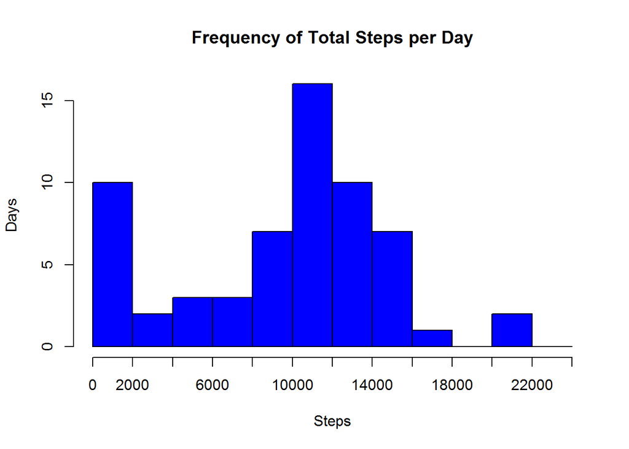

```r
TotalStepsByDay <- aggregate(ds$steps,list(date=ds$date),sum,na.rm=TRUE)
xAxisBreakdown = seq(from=0,to=25000,by=2000)
hist(TotalStepsByDay$x,
      breaks = xAxisBreakdown,
      main="Frequency of Total Steps per Day",
      col="blue",
      xlab="Steps",
      ylab="Days",
      xaxt="n")
axis(side=1,at=xAxisBreakdown,labels=xAxisBreakdown)
```

plot for step2

```r
stepMean <- mean(TotalStepsByDay$x,na.rm=T)
stepMedian <- median(TotalStepsByDay$x,na.rm=T)
print(paste("The Mean number of steps per day is",round(stepMean,1)))
```

```
## [1] "The Mean number of steps per day is 9354.2"
```

```r
print(paste("The Median number of steps per day is",round(stepMedian,1)))
```

```
## [1] "The Median number of steps per day is 10395"
```

## Step 3: Time Series Pattern

Data frame is created with the average steps per interval across all days. Then a time series plot is created to see average activity rates throughout the day.

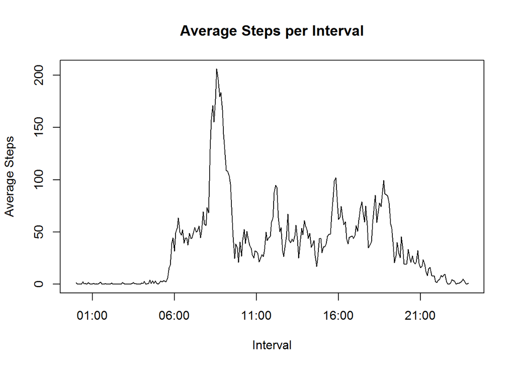

```r
#First we need to convert the 5-minute 24-hour clock intervals into a time #class; the next few steps will do that.

#The hours of the interval are equal to the first two digits (interval divided #by 100, with remainder tossed)
intHours <- ds$interval %/% 100

#Now add a leading 0 when the hours are one digit
intHours <- ifelse(intHours < 10,paste("0",intHours,sep=""),intHours)

#The minutes of the interval are equal to the second two digits (the remainder #after dividing by 100)
intMinutes <- ds$interval %% 100

#Now add a leading 0 when the minutes are one digit
intMinutes <- ifelse(intMinutes < 10,paste("0",intMinutes,sep=""),intMinutes)

#Now put the minutes and hours together and convert to a time with strptime()
intTime <- paste(intHours,":",intMinutes,sep="")
intTime <- strptime(intTime,format="%H:%M")

#Now add the time variable back into the original data set
ds <- cbind(ds,intTime)

#We now have the time in the data frame as a time, so we can compute the mean #number of steps for each time interval and plot the result
SPI <- aggregate(ds$steps,list(intTime=ds$intTime),mean,na.rm=TRUE)
plot(SPI$intTime,SPI$x,
     type = "l",
     main = "Average Steps per Interval",
     xlab = "Interval",
     ylab = "Average Steps")
```

plot for step3

Also compute which interval has the highest average

```r
MaxStepAvg <- max(SPI$x)
IntervalWithMaxStepAvg <- SPI$intTime[SPI$x == MaxStepAvg]

#The highest average occurs at `r intTime` 08:35 and is equal to
#`r IntervalWithMaxStepAvg` 206.2.
```

## Step 4: Dealing with Missing Values

Part a

```r
countNAs <- sum(is.na(ds$steps))
```

There are a total of 2304 missing values.

Part b

```r
#Renaming column x in data frame SPI to what it actually represents
names(SPI)[names(SPI)=="x"] <- "avgIntervalSteps"

#Now merge the average back into the dataframe by intTime
dsWithAvg <- merge(x=ds,y=SPI,by="intTime",all.x=TRUE)

#It's not strictly necessary, but I'll reorder the new dataframe to preserve #the date,interval ordering of the original file
dsWithAvg <- dsWithAvg[order(dsWithAvg$date,dsWithAvg$intTime),]

#Now create another column that uses the steps, if available, and the #avgIntervalSteps otherwise.
dsWithAvg$imputedSteps <- ifelse(is.na(dsWithAvg$steps),
                                 dsWithAvg$avgIntervalSteps,
                                 dsWithAvg$steps)
```

Part c #I am copying the code directly from Step 2, then changing df to dfWithAvg and #steps to imputedSteps. Other variable names change similarly.

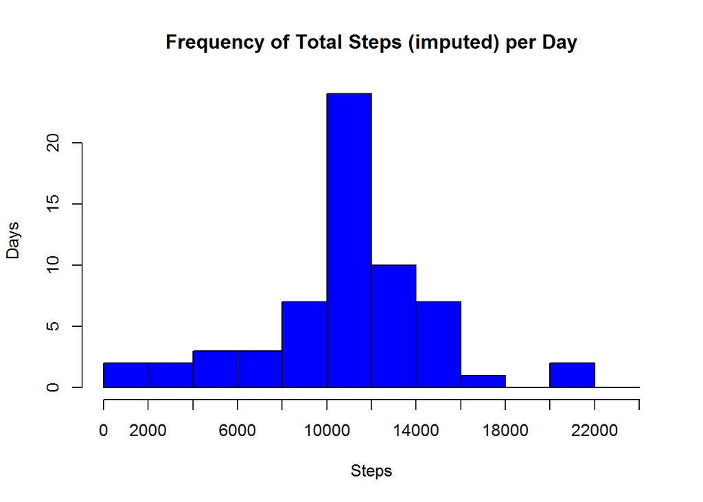

```r
TotalStepsByDayImputed <- aggregate(dsWithAvg$imputedSteps,list(date=dsWithAvg$date),sum,na.rm=TRUE)
xAxisBreakdown = seq(from=0,to=25000,by=2000)
hist(TotalStepsByDayImputed$x,
      breaks = xAxisBreakdown,
      main="Frequency of Total Steps (imputed) per Day",
      col="blue",
      xlab="Steps",
      ylab="Days",
      xaxt="n")
axis(side=1,at=xAxisBreakdown,labels=xAxisBreakdown)
```

plot for step 4-3

## Step 5

The day of the week added to the dfWithAvg data frame, a new variable created for Weekend or Weekday, then aggregate() used to summarize the data. Then comparison plots created by using the lattice plotting system.

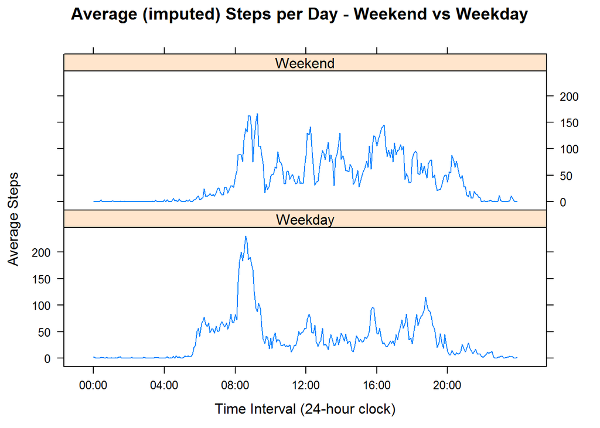

```r
dsWithAvg$weekday <- weekdays(dsWithAvg$date)
dsWithAvg$weekendFlag <- ifelse(dsWithAvg$weekday=="Saturday" | dsWithAvg$weekday=="Sunday","Weekend","Weekday")

#This line computes the average steps / day for weekend and weekdays
SPI2 <- aggregate(dsWithAvg$imputedSteps,list(intTime=dsWithAvg$intTime,weekendFlag=dsWithAvg$weekendFlag),mean,na.rm=TRUE)

#Before plotting, set up the sequence to appear on the x-axis
#(This is based on StackOverflow post 14243834)
xn <- seq(min(dsWithAvg$intTime),max(dsWithAvg$intTime),by="4 hour")

#Draw the plot with the x-axis in HH:MM format
xyplot(x~intTime|weekendFlag,
       data=SPI2,
       type="l",
       layout=c(1,2),
       xlab = "Time Interval (24-hour clock)",
       ylab = "Average Steps",
       main = "Average (imputed) Steps per Day - Weekend vs Weekday",
       scales=list(
                    x=list(
                            at=xn,
                            labels=format(xn,"%H:%M")
                            )
                  )
        )
```

plot for step5

Weekdays and weekends have activity pattern difference. Weekdays have spike of activity around 8am and less activity during a day. Weekends have more spikes of activity during a day.

```
rmarkdown::render('PA1_template.Rmd',
                  output_file='PA1_template.md')
```